# Análisis de Regresión lineal múltiple: Gasto en Publicidad y cantidad de empleados vs Ventas

Equipo 5

2023-11-21

##

# Contexto

. Imagina que tienes un conjunto de datos que contiene información sobre ventas de una tienda. Queremos predecir las ventas totales (en miles de dólares) basándonos en dos factores: el gasto en publicidad (también en miles de dólares) y el número de empleados en la tienda. ##

# Datos de ejemplo

| Ventas (Y) | Publicidad (X1) | Empleados (X2) |
| --- | --- | --- |
| 58 | 3.4 | 8 |
| 54 | 2.6 | 7 |
| 66 | 4.5 | 9 |
| 57 | 3.0 | 8 |
| 59 | 3.6 | 7 |
| 69 | 4.7 | 10 |
| 55 | 2.8 | 7 |
| 60 | 3.3 | 8 |
| 62 | 3.8 | 7 |
| 68 | 4.2 | 9 |

##

# Solución en R

###

## 1.Crear el conjunto de datos

Primero, vamos a crear un conjunto de datos de ejemplo.

```r
ventas <- data.frame(
    Venta = c(58, 54, 66, 57, 59, 69, 55, 60, 62, 68),
    Publicidad = c(3.4, 2.6, 4.5, 3.0, 3.6, 4.7, 2.8, 3.3, 3.8, 4.2),
    Empleados = c(8, 7, 9, 8, 7, 10, 7, 8, 7, 9)
)
```

###

## Explorar los datos

Vamos a revisar las estadísticas básicas y visualizar los datos.

```r
summary(ventas)
```

```
##      Venta         Publicidad      Empleados
##  Min.   :54.00   Min.   :2.600   Min.   : 7.00
##  1st Qu.:57.25   1st Qu.:3.075   1st Qu.: 7.00
##  Median :59.50   Median :3.500   Median : 8.00
##  Mean   :60.80   Mean   :3.590   Mean   : 8.00
##  3rd Qu.:65.00   3rd Qu.:4.100   3rd Qu.: 8.75
##  Max.   :69.00   Max.   :4.700   Max.   :10.00
```

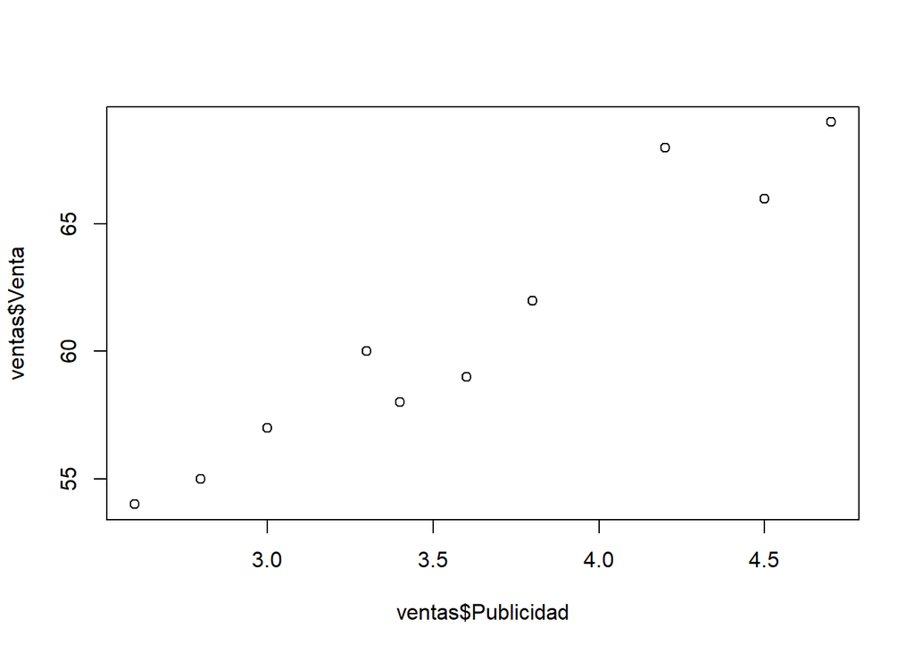

```r
plot(ventas$Publicidad, ventas$Venta)
```

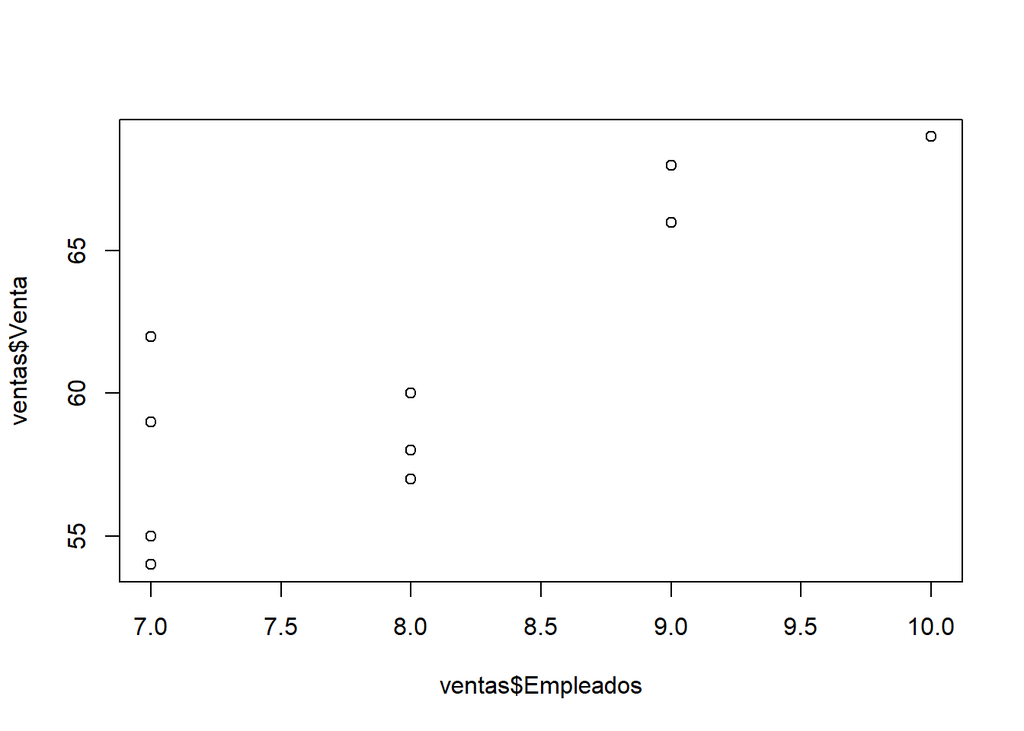

```r
plot(ventas$Empleados, ventas$Venta)
```

###

## Creamos el modelo de regresión multiple

Ahora , con la ayuda de R crearemos el modelo de regresión multiple con la ayuda de la función lm

```r
modelo <- lm(Venta ~ Publicidad + Empleados, data=ventas)
```

-lm(Venta ~ Publicidad + Empleados, data=ventas): La función lm() es utilizada para ajustar modelos lineales.

-Venta ~ Publicidad + Empleados: Esta es la fórmula del modelo. El signo ~ se lee como “modelado por”. Venta es la variable dependiente que estamos tratando de predecir, y Publicidad y Empleados son las variables independientes que se utilizan para hacer la predicción. El signo + no indica adición en este contexto, sino que está incluyendo múltiples predictores en el modelo.

###

## Resumen del modelo e interpretación de resultados

```r
summary(modelo)
```

```
##
## Call:
## lm(formula = Venta ~ Publicidad + Empleados, data = ventas)
##
## Residuals:
##     Min      1Q  Median      3Q     Max
## -1.6513 -0.7742 -0.1305  0.7398  2.5163
##
## Coefficients:
##             Estimate Std. Error t value Pr(>|t|)
## (Intercept)  31.1299     3.6189   8.602 5.72e-05 ***
## Publicidad    6.0460     1.0565   5.722 0.000719 ***
## Empleados     0.9956     0.7126   1.397 0.205050
## ---
## Signif. codes:  0 '***' 0.001 '**' 0.01 '*' 0.05 '.' 0.1 ' ' 1
##
## Residual standard error: 1.394 on 7 degrees of freedom
## Multiple R-squared:  0.9464, Adjusted R-squared:  0.9311
## F-statistic: 61.78 on 2 and 7 DF,  p-value: 3.568e-05
```

###

## 5.Predicciones

Si se quieren predecir las ventas con un nuevo conjunto de datos de publicidad y empleados, se puede hacer así

```r
predict(modelo, newdata=data.frame(Publicidad=5, Empleados=8))
```

```
##        1
## 69.32483
```

El resultado de la predicción es aproximadamente 69.32483. Esto significa que, según el modelo, si una tienda gasta 5 unidades en publicidad y tiene 8 empleados, se esperaría que las ventas sean de aproximadamente 69.32483 unidades.